**Notebook with EDA and Training**

*Roger González*

# LIBRARIES INSTALLATION

```python
!pip install ultralytics roboflow
```

[output not shown]

```python
import pandas as pd
import numpy as np

from roboflow import Roboflow
from ultralytics import YOLO
import yaml
from collections import Counter
import cv2

import glob
import os
from IPython.display import Image, display
from IPython import display
display.clear_output()

#Representación de gráficos
import matplotlib.pyplot as plt
import matplotlib.image as mpimg
import seaborn as sns

from datetime import date

#from google.colab import files, userdata
```

# FUNCTIONS

```python
#def display_image(image):
#  fig = plt.figure(figsize=(20, 15))
#  plt.grid(False)
#  plt.imshow(image)
```

```python
def display_image(image_path, axis_show='off'):
  img = mpimg.imread(image_path)
  plt.figure(figsize=(10, 10))
  plt.imshow(img)
  plt.axis(axis_show)

  return plt.show()
```

```python
#Function that counts files
def count_images(tipo):
    ruta = f"{base_path}/{tipo}/images"
    if os.path.exists(ruta):
        cantidad = len(os.listdir(ruta))
        print(f"{tipo.upper()}: {cantidad} images")
    else:
        print(f"{tipo.upper()}: Directory doesn't exist")

    return cantidad
```

```python
def show_image_annotated(base_path, img_id):

    '''Function that shows an image with its respective bboxes
    It takes the base_path which is the dataset.location and
    img_id (without .jpg or .txt format)'''

    # 1. Path configuration
    path_img = f"{base_path}/train/images/{img_id}.jpg"
    path_label = f"{base_path}/train/labels/{img_id}.txt"

    # 2. Loading image
    image = cv2.imread(path_img)
    image = cv2.cvtColor(image, cv2.COLOR_BGR2RGB)
    h, w, _ = image.shape
    size = h, w, _
    print(size)

    # 3. Read labels and draw
    if os.path.exists(path_label):
        with open(path_label, 'r') as f:
            for line in f:
                cls_id, x_c, y_c, wb, hb = map(float, line.split())

                # #YOLO conversion (center, width, height) to pixel coordinates (x1, y1, x2, y2)
                x1 = int((x_c - wb/2) * w)
                y1 = int((y_c - hb/2) * h)
                x2 = int((x_c + wb/2) * w)
                y2 = int((y_c + hb/2) * h)

                # Bboxes drawing
                color = (0, 255, 122)
                cv2.rectangle(image, (x1, y1), (x2, y2), color, 3)

                # Adding Class Name
                label = class_names_dict.get(int(cls_id), str(int(cls_id)))
                cv2.putText(image, label, (x1, y1 - 10), cv2.FONT_HERSHEY_SIMPLEX, 0.9, color, 2)

    # 4. Show annotated image
    plt.figure(figsize=(10, 6))
    plt.imshow(image)
    plt.axis('off')
    plt.title(f"Image: {img_id}")
    image = plt.show()
```

# Downloading Dataset

I cloned a dataset from RoboFlow to my profile and added some more labels to more images.

This dataset (V3) is part of the main dataset with rotation modification (between -15° and +15°).

**Link: https://app.roboflow.com/rogergs94/tfm_construction_roger/3**

```python
today = date.today()
```

```python
#I'm creating an environment variable for the API_key
API_key = userdata.get('ROBOFLOW_API_KEY')
rf = Roboflow(api_key = API_key)
```

```python
project = rf.workspace("rogergs94").project("tfm_construction_roger")
version = project.version(3) #Version = 3
dataset = version.download("yolov8")
```

```
loading Roboflow workspace...
loading Roboflow project...
```

```
Downloading Dataset Version Zip in tfm_construction_roger-3 to yolov8:: 100%|██████████| 337161/337161 [00:12<00:00, 27490.36it/s]
```

```
Extracting Dataset Version Zip to tfm_construction_roger-3 in yolov8:: 100%|██████████| 6360/6360 [00:01<00:00, 4491.27it/s]
```

```python
# Where the dataset has been downloaded?
base_path = dataset.location
print(f"Dataset path: {base_path}")
```

```
Dataset path: /content/tfm_construction_roger-3
```

# EDA & Data Preprocessing

First, we open the data.yaml which contains all the information and directories of the dataframe:

```python
# Open data.yaml
with open(f'{base_path}/data.yaml', 'r') as file:
    data = yaml.safe_load(file)

data
```

```
{'names': ['helmet', 'no-helmet', 'no-vest', 'person', 'vest'],
 'nc': 5,
 'roboflow': {'license': 'CC BY 4.0',
  'project': 'construction-safety-gsnvb-4gguw',
  'url': 'https://universe.roboflow.com/rogergs94/construction-safety-gsnvb-4gguw/dataset/3',
  'version': 3,
  'workspace': 'rogergs94'},
 'test': '../test/images',
 'train': '../train/images',
 'val': '../valid/images'}
```

```python
# Directories:
print(f'Train directory: {data["train"]}')
print(f'Test directory: {data["test"]}')
print(f'Val directory: {data["val"]}')
```

```
Train directory: ../train/images
Test directory: ../test/images
Val directory: ../valid/images
```

## Image and Instance Analysis

### Total images in the dataset

```python
# How many images does the dataframe have?
print("-" * 30)

train_count = count_images("train")
test_count  = count_images("test")
valid_count = count_images("valid")

print("-" * 30)

total = train_count + test_count + valid_count
print(f"TOTAL IMAGES: {total}")
```

[output not shown]

### Which and how many classes?

```python
# What classes are there in my dataset?
class_names = data["names"]
class_names #It returns a list with the class names
```

```
['helmet', 'no-helmet', 'no-vest', 'person', 'vest']
```

```python
# How many instances per class?
def count_classes(split):
  # 1. Getting the "labels" directory
    labels_path = os.path.join(base_path, split, "labels")

    counter = Counter()
    if not os.path.exists(labels_path):
        return counter

    for file in os.listdir(labels_path):
        if file.endswith(".txt"):
            with open(os.path.join(labels_path, file), "r") as f:
                for line in f:
                    class_id = int(line.strip().split()[0])
                    counter[class_id] += 1

    return counter
```

```python
total_counter = count_classes("train") + count_classes("test") + count_classes("valid")
total_counter
```

```
Counter({4: 3481, 3: 7489, 0: 6734, 2: 2347, 1: 311})
```

```python
data_classes_list = []
for class_id, count in total_counter.items():
  class_name = class_names[class_id]
  data_classes_list.append({
      "class_id": class_id,
      "class_name": class_name,
      "count": count
  })

df_classes = pd.DataFrame(data_classes_list)
df_classes.sort_values(by="count", ascending=False).reset_index(drop=True)
```

|  | class_id | class_name | count |
| --- | --- | --- | --- |
| 0 | 3 | person | 7489 |
| 1 | 0 | helmet | 6734 |
| 2 | 4 | vest | 3481 |
| 3 | 2 | no-vest | 2347 |
| 4 | 1 | no-helmet | 311 |

```python
total_classes = df_classes["count"].sum()

df_classes["count_norm"] = df_classes["count"]/total_classes

df_classes = df_classes.sort_values(by="count_norm", ascending=False).reset_index(drop=True)
df_classes
```

|  | class_id | class_name | count | count_norm |
| --- | --- | --- | --- | --- |
| 0 | 3 | person | 7489 | 0.367793 |
| 1 | 0 | helmet | 6734 | 0.330714 |
| 2 | 4 | vest | 3481 | 0.170956 |
| 3 | 2 | no-vest | 2347 | 0.115264 |
| 4 | 1 | no-helmet | 311 | 0.015274 |

```
<BarContainer object of 5 artists>
```

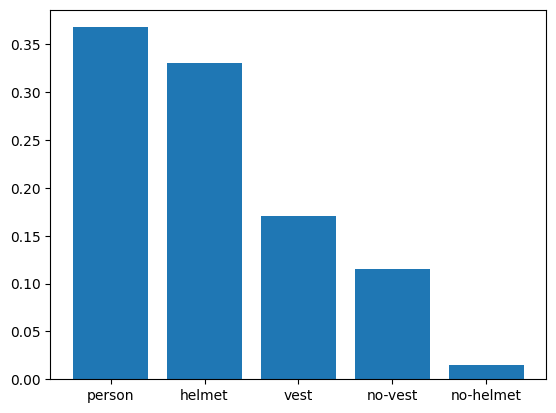

```python
# Representation
x = df_classes["class_name"]
y = df_classes["count_norm"].sort_values(ascending=False)
fig, ax = plt.subplots()
ax.bar(x, y)
```

We can see that "person" is the dominant class followed by "helmet" and then "vest". There are only 311 instances for no-helmet which can be challenging for the model to predict this class.

## EDA

I have created a dataframe with the **training** data. I want to analyze the distribution of the bounding boxes across instances, see how much space each bounding box occupies relative to the total image, and determine how many instances there are per image. To achieve this, I have built a dataset calculating the following:

- **class**: The name of the category. This allows for the detection of class imbalance.
- **x, y**: The coordinates of the object's center. These are normalized values (from 0 to 1) used to detect whether objects are always centered or if the dataset has spatial variety.
- **w, h**: The relative width and height. These indicate whether the objects are predominantly wide, tall, or square.
- **area_pct**: Calculated as (w⋅h)⋅100. This is vital for identifying small objects. If the area is less than 0.5%, the model will have difficulty detecting them without special techniques.
- **instances_per_img**: The number of objects in the image from which that row originates. This indicates whether the scenes are simple (1 object) or congested (many objects), which influences parameters such as Non-Max Suppression (NMS).

**Minority Classes**: If we notice a class has 10 times fewer instances than the others, the bar chart will indicate that it needs to perform class-specific Data Augmentation or acquire more images.

**Very Small Boxes**: If the area chart shows many values near 0, consider that models like YOLOv8 struggle with objects smaller than 10-20 pixels. It may be needed to upscale images to a higher resolution (e.g., from 640px to 1280px).

**Class Correlation**: If "Person" always appears alongside "Helmet," a co-occurrence matrix (label confusion matrix) will help understand the context the AI model is learning.

```python
# --- CONFIGURATION ---
path_labels = f'{base_path}/train/labels'
class_names_dict = {i: name for i, name in enumerate(class_names)}

# --- DATA EXTRACTION ---
data_list = []

for label_file in glob.glob(os.path.join(path_labels, "*.txt")):
    # It will extract the file name (ie: "image_01") without the .txt extension
    file_name = os.path.splitext(os.path.basename(label_file))[0]

    with open(label_file, 'r') as f:
        lines = f.readlines()
        instances_in_image = len(lines)
        for line in lines:
            parts = line.split()
            if len(parts) == 5:
                cls_id = int(parts[0])
                name = class_names_dict.get(cls_id, f"ID_{cls_id}")

                data_list.append({
                    'image_name': file_name,
                    'class': name,
                    'x': float(parts[1]),
                    'y': float(parts[2]),
                    'w': float(parts[3]),
                    'h': float(parts[4]),
                    'area_pct': float(parts[3]) * float(parts[4]) * 100,
                    'instances_per_img': instances_in_image
                })

# Transformation into a dataframe
df = pd.DataFrame(data_list)
df.head()
```

|  | image_name | class | x | y | w | h | area_pct | instances_per_img |
| --- | --- | --- | --- | --- | --- | --- | --- | --- |
| 0 | ppe_0985_jpg.rf.1b05922b87c99e6cb46645c3c8cd91a9 | vest | 0.815430 | 0.521484 | 0.363932 | 0.357910 | 13.025506 | 9 |
| 1 | ppe_0985_jpg.rf.1b05922b87c99e6cb46645c3c8cd91a9 | vest | 0.487956 | 0.490723 | 0.367188 | 0.330078 | 12.120056 | 9 |
| 2 | ppe_0985_jpg.rf.1b05922b87c99e6cb46645c3c8cd91a9 | vest | 0.200521 | 0.472412 | 0.332031 | 0.289551 | 9.613991 | 9 |
| 3 | ppe_0985_jpg.rf.1b05922b87c99e6cb46645c3c8cd91a9 | person | 0.758464 | 0.582275 | 0.483073 | 0.835449 | 40.358289 | 9 |
| 4 | ppe_0985_jpg.rf.1b05922b87c99e6cb46645c3c8cd91a9 | person | 0.468424 | 0.583984 | 0.560547 | 0.832031 | 46.639252 | 9 |

#### Image Verification

```python
# Comprobación de imágenes
#Cojo una imagen al azar para chequear
img_id = "helmetcolours_1500_jpg.rf.3e66581353579ec33b513cfcf9604cf1"

print(df[df["image_name"] == img_id].groupby("class").size())
df[df["image_name"] == img_id]
```

```
class
helmet    3
person    3
vest      3
dtype: int64
```

|  | image_name | class | x | y | w | h | area_pct | instances_per_img |
| --- | --- | --- | --- | --- | --- | --- | --- | --- |
| 2205 | helmetcolours_1500_jpg.rf.3e66581353579ec33b51... | helmet | 0.687000 | 0.192460 | 0.230667 | 0.335979 | 7.749912 | 9 |
| 2206 | helmetcolours_1500_jpg.rf.3e66581353579ec33b51... | helmet | 0.418000 | 0.675265 | 0.038000 | 0.068783 | 0.261376 | 9 |
| 2207 | helmetcolours_1500_jpg.rf.3e66581353579ec33b51... | helmet | 0.489667 | 0.670635 | 0.023333 | 0.034392 | 0.080247 | 9 |
| 2208 | helmetcolours_1500_jpg.rf.3e66581353579ec33b51... | vest | 0.759667 | 0.691799 | 0.408000 | 0.546296 | 22.288889 | 9 |
| 2209 | helmetcolours_1500_jpg.rf.3e66581353579ec33b51... | vest | 0.441333 | 0.804894 | 0.098000 | 0.206349 | 2.022222 | 9 |
| 2210 | helmetcolours_1500_jpg.rf.3e66581353579ec33b51... | vest | 0.516333 | 0.759921 | 0.073333 | 0.165344 | 1.212522 | 9 |
| 2211 | helmetcolours_1500_jpg.rf.3e66581353579ec33b51... | person | 0.723667 | 0.487434 | 0.486000 | 0.974868 | 47.378571 | 9 |
| 2212 | helmetcolours_1500_jpg.rf.3e66581353579ec33b51... | person | 0.446000 | 0.814153 | 0.124000 | 0.371693 | 4.608995 | 9 |
| 2213 | helmetcolours_1500_jpg.rf.3e66581353579ec33b51... | person | 0.520667 | 0.814815 | 0.100000 | 0.370370 | 3.703704 | 9 |

```python
img_path = "/content/tfm_construction_roger-3/train/images/helmetcolours_1500_jpg.rf.3e66581353579ec33b513cfcf9604cf1.jpg"
```

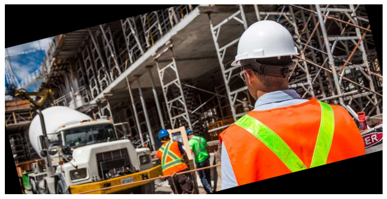

```python
display_image(image_path=img_path, axis_show='off')
```

```
(756, 1500, 3)
```

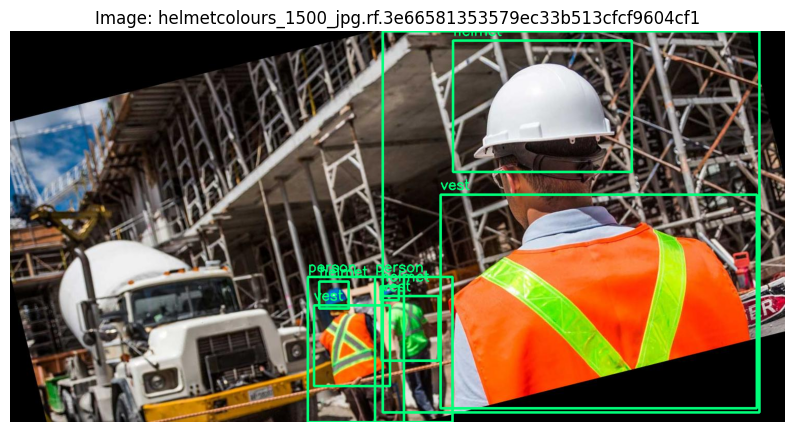

```python
show_image_annotated(base_path, "helmetcolours_1500_jpg.rf.3e66581353579ec33b513cfcf9604cf1")
```

#### Image Analysis

It shows an image analysis to understad how many instances there are in each image.

```python
# Checking amount of images in training
df["image_name"].nunique()
```

```
2965
```

```python
# Instances per image in training
df_instances_per_img = df.groupby(by="image_name").agg(
    {"class":"nunique",
     "instances_per_img":"max"}
).sort_values(by="instances_per_img", ascending=False).reset_index()

df_instances_per_img.head()
```

|  | image_name | class | instances_per_img |
| --- | --- | --- | --- |
| 0 | ppe_0604_jpg.rf.dcd50aa024e76d261e4ae44536f154dd | 4 | 39 |
| 1 | ppe_0604_jpg.rf.fada3f91c5648270c83457b605c0b755 | 4 | 39 |
| 2 | ppe_0604_jpg.rf.fe923e56ca7c0dd4236d5e2d7ed1edd6 | 4 | 39 |
| 3 | ppe_0444_jpg.rf.4dcc3091adf3a2768f0f147a0db5f255 | 3 | 34 |
| 4 | ppe_0444_jpg.rf.8093f0251bdb4111a26fd273ea254016 | 3 | 34 |

```python
# How many images there are per "instances_per_img" (total bboxes)?
df_density = df_instances_per_img.groupby(by="instances_per_img").agg(
    {"image_name":"count"}
).sort_values("image_name",ascending=False)

# Group by instances_per_img and calculate the mean class diversity for each group.

df_density["avg_diversity"] = df_instances_per_img.groupby("instances_per_img")["class"].mean()
df_density = df_density.rename(columns={"image_name": "total_images"})
df_density = df_density.reset_index()

df_density.head(10)
```

|  | instances_per_img | total_images | avg_diversity |
| --- | --- | --- | --- |
| 0 | 3 | 936 | 2.958333 |
| 1 | 6 | 597 | 3.068677 |
| 2 | 9 | 276 | 3.115942 |
| 3 | 2 | 205 | 1.858537 |
| 4 | 4 | 153 | 2.078431 |
| 5 | 5 | 145 | 2.751724 |
| 6 | 12 | 85 | 3.105882 |
| 7 | 7 | 84 | 2.785714 |
| 8 | 8 | 80 | 2.887500 |
| 9 | 15 | 65 | 3.215385 |

We can observe that there are 936 images with 3 bboxes or instances per image, and 597 images with 6 instances per image, accounting for more than half of the training dataframe. This is important for when the model needs to infer multiple classes within the same frame or image.

Furthermore, the avg_diversity (average diversity) column shows that when 1 object or instance appears, 1 class is present. In **images with 2 instances**, the average class variety is 1.85. Similarly, in **images with 3 instances**, the average is 2.95, meaning that in most of all images with 3 objects, the three classes appear together. However, when there are **4 instances**, the average drops to 2.07, indicating that although there are more physical objects in the photo, the variety of labels decreases.

```
Ignoring `palette` because no `hue` variable has been assigned.


Passing `palette` without assigning `hue` is deprecated and will be removed in v0.14.0. Assign the `x` variable to `hue` and set `legend=False` for the same effect.
```

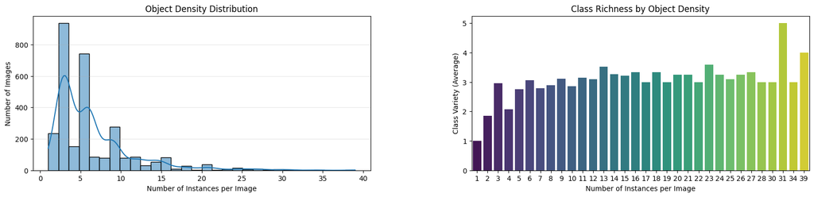

```python
# --- VISUALIZATION ---
fig, axes = plt.subplots(1, 2, figsize=(20, 4))
plt.subplots_adjust(wspace=0.3)

# PLOT 1: Object Density (What you already had)
sns.histplot(df_instances_per_img['instances_per_img'], ax=axes[0], bins=30, kde=True, palette='skyblue')
axes[0].set_title('Object Density Distribution', fontsize=12)
axes[0].set_xlabel('Number of Instances per Image')
axes[0].set_ylabel('Number of Images')
axes[0].grid(axis='y', alpha=0.3)

# PLOT 2: Class Diversity (Strategy Justification)
sns.barplot(data=df_density, x='instances_per_img', y='avg_diversity', ax=axes[1], palette='viridis')
# Note: Fixed the title target for axes[1]
axes[1].set_title('Class Richness by Object Density', fontsize=12)
axes[1].set_xlabel('Number of Instances per Image')
axes[1].set_ylabel('Class Variety (Average)')

plt.show()
```

The **Object Density Distribution** chart above shows that:

This suggests that the model may face challenges when tasked with diagnosing frames containing many classes or a large number of elements."

#### Instances Analysis

```python
# Retrieve the df
df.head()
```

|  | image_name | class | x | y | w | h | area_pct | instances_per_img |
| --- | --- | --- | --- | --- | --- | --- | --- | --- |
| 0 | ppe_0985_jpg.rf.1b05922b87c99e6cb46645c3c8cd91a9 | vest | 0.815430 | 0.521484 | 0.363932 | 0.357910 | 13.025506 | 9 |
| 1 | ppe_0985_jpg.rf.1b05922b87c99e6cb46645c3c8cd91a9 | vest | 0.487956 | 0.490723 | 0.367188 | 0.330078 | 12.120056 | 9 |
| 2 | ppe_0985_jpg.rf.1b05922b87c99e6cb46645c3c8cd91a9 | vest | 0.200521 | 0.472412 | 0.332031 | 0.289551 | 9.613991 | 9 |
| 3 | ppe_0985_jpg.rf.1b05922b87c99e6cb46645c3c8cd91a9 | person | 0.758464 | 0.582275 | 0.483073 | 0.835449 | 40.358289 | 9 |
| 4 | ppe_0985_jpg.rf.1b05922b87c99e6cb46645c3c8cd91a9 | person | 0.468424 | 0.583984 | 0.560547 | 0.832031 | 46.639252 | 9 |

```python
df.groupby(by="class").agg(
    {"x": "mean",
    "y": "mean",
    "w": "mean",
    "h": "mean",
    "area_pct":"mean",
    "instances_per_img":"mean"}
).round(4)
```

| class | x | y | w | h | area_pct | instances_per_img |
| --- | --- | --- | --- | --- | --- | --- |
| helmet | 0.4997 | 0.3200 | 0.1233 | 0.1329 | 2.3088 | 10.2315 |
| no-helmet | 0.4722 | 0.3495 | 0.0870 | 0.1048 | 1.1612 | 12.5036 |
| no-vest | 0.4981 | 0.5799 | 0.2122 | 0.3292 | 8.6798 | 9.8192 |
| person | 0.4997 | 0.5608 | 0.2427 | 0.6082 | 17.7958 | 9.8106 |
| vest | 0.5029 | 0.5581 | 0.1896 | 0.3340 | 7.9311 | 10.6073 |

#### Visualization

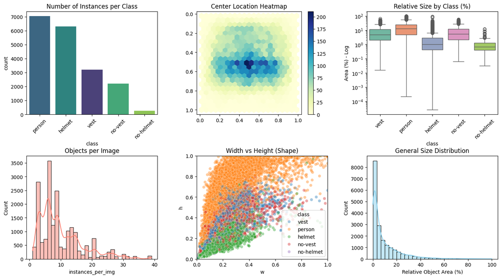

```python
# --- VISUALIZATION ---
# Define 2 rows and 3 columns (6 spaces)
fig, axes = plt.subplots(2, 3, figsize=(17, 9))
plt.subplots_adjust(hspace=0.4, wspace=0.3)

# 1. Class Distribution
sns.countplot(data=df, x='class', ax=axes[0,0], palette='viridis', hue='class', legend=False, order=df['class'].value_counts().index)
axes[0,0].set_title('Number of Instances per Class', fontsize=12)
axes[0,0].tick_params(axis='x', rotation=45)

# 2. Spatial Distribution (Heatmap)
hb = axes[0,1].hexbin(df['x'], df['y'], gridsize=20, cmap='YlGnBu')
fig.colorbar(hb, ax=axes[0,1]) # Añadimos barra de color para entender la densidad
axes[0,1].set_title('Center Location Heatmap', fontsize=12)
axes[0,1].invert_yaxis()

# 3. Boxplot of Area by Class
sns.boxplot(data=df, x='class', y='area_pct', palette='Set2', ax=axes[0,2], hue='class', legend=False)
axes[0,2].set_yscale('log') # Importante: log para ver bien objetos pequeños (cascos)
axes[0,2].set_title('Relative Size by Class (%)', fontsize=12)
axes[0,2].set_ylabel('Area (%) - Log')
axes[0,2].tick_params(axis='x', rotation=45)

# 4. Object Density per Image
sns.histplot(df['instances_per_img'], bins=max(10, df['instances_per_img'].nunique()), kde=True, ax=axes[1,0], color='salmon')
axes[1,0].set_title('Objects per Image', fontsize=12)

# 5. Aspect Ratio (Scatter Plot)
sns.scatterplot(data=df, x='w', y='h', hue='class', alpha=0.4, ax=axes[1,1])
axes[1,1].set_title('Width vs Height (Shape)', fontsize=12)
axes[1,1].set_xlim(0, 1)
axes[1,1].set_ylim(0, 1)

# 6. Total Area Distribution (General Histogram)
sns.histplot(df['area_pct'], bins=30, kde=True, ax=axes[1,2], color='skyblue')
axes[1,2].set_title('General Size Distribution', fontsize=12)
axes[1,2].set_xlabel('Relative Object Area (%)')

plt.show()
```

I have conducted a detailed analysis of the instances to evaluate potential class imbalance and the geometric characteristics of the bounding boxes. The following visualizations represent:

- **Number of Instances per Class**: This reveals a significant class imbalance among the **vest**, **no-vest**, and **no-helmet** categories. This disparity must be addressed to ensure the model does not become biased toward the majority classes.
- **Center Location Heatmap**: This shows the density of object centers within the frame. The concentration suggests that most workers were captured at a similar distance from the camera. The low density at the top and bottom edges indicates a lack of objects in extreme high-angle or low-angle perspectives. Consequently, the model might face challenges detecting objects located near the image boundaries.
- **Relative Size per Class (%) (Logarithmic Scale)**: This displays the distribution of the area occupied by each class relative to the total image size. There is a high frequency of large instances, especially for the **"person"** class. The fact that helmets are categorized as small objects justifies the use of architectures like **YOLO**, which incorporate specialized layers for small-scale object detection.
- **Objects per Image**: This histogram illustrates the number of instances in each photograph. While the majority of images contain fewer than 10 objects, there is a **"long tail"** in the distribution reaching up to 40 instances per image.
- **Width vs. Height (Shape)**: This scatter plot correlates the width ($w$) and height ($h$) of each bounding box. Most data points follow a vertical trend ($h > w$), which is logically consistent with human morphology.
- **General Size Distribution**: The distribution indicates a high prevalence of very small instances. This suggests the model may struggle with distant objects, as the vast majority of instances occupy less than 10% of the total image area.

**Class Imbalance Mitigation Strategy**

A **pronounced imbalance among the dataset classes** is observed in the Number of Instances per Class, particularly within the "no-vest," "vest," and "no-helmet" categories, which exhibit a significantly lower number of instances compared to the majority classes.

To mitigate this imbalance, I propose the **incorporation of new images containing these minority classes** to achieve a more balanced dataset and promote more stable model training.

In this case, I will implement **data augmentation** focused primarily on these minority class instances (no-helmet, no-vest, and vest), while making a deliberate effort to avoid unnecessarily duplicating dominant classes.

```python
class_names
```

```
['helmet', 'no-helmet', 'no-vest', 'person', 'vest']
```

In order to perform data augmentation exclusively on the under-represented classes, I aim to identify images that contain **only minority classes** without the presence of majority classes. This approach is designed to prevent the unnecessary duplication of instances that are already over-represented in the dataset, thereby maintaining a healthier class ratio and avoiding model overfitting toward dominant categories.

```python
labels_path = f"{base_path}/train/labels"

minor_classes = {1, 2, 4} #I retrieve the no-helmet, no-vest and vest classes
counter = Counter()

for lbl in os.listdir(labels_path):
    if not lbl.endswith(".txt"):
        continue

    with open(os.path.join(labels_path, lbl)) as f:
        classes = {int(line.split()[0]) for line in f}

    has_minor = classes & minor_classes

    if not has_minor:
        continue

    if classes <= minor_classes:
        counter["solo_minor"] += 1
    else:
        counter["minor + others"] += 1

print(counter)
```

```
Counter({'minor + others': 2499})
```

**Selective Augmentation Feasibility Analysis**

The images containing minority classes are categorized into two critical groups to determine which can be duplicated or augmented without negatively impacting the dataset's balance:

- **solo_minor (Pure Images)**: These are images that exclusively contain the labels I want to boost (**no-helmet, no-vest, and vest**) and nothing else.
- **minor + others (Mixed or "Contaminated" Images)**: These images contain at least one minority class but also include majority classes (such as **"person"** or **"helmet"**). If I duplicated these images to increase the representation of a "vest," I would be simultaneously increasing the count of majority classes like "person."

In conclusionm the results show that there are no images in the dataset where minority classes appear alone, as they are intrinsically linked to the majority classes. Consequently, it will be necessary to implement **targeted data augmentation** techniques. Essentially, every time a vest or a missing helmet is present, there is a "person" in the same frame.

# Phase I. Baseline and YOLO MODEL COMPARISON

Here I have decided to perform a comparative analysis between the **YOLOv8** and **YOLOv11** model families. The objective is to determine which model is better suited for diagnosing the specific classes in this dataset and to evaluate their relative performance based on key metrics.

To ensure a fair comparison and prevent overfitting, I implemented an **Early Stopping callback** with a patience of 5 epochs. This technique allows each model to autonomously reach its optimal generalization point. Consequently, the comparison is not based on an arbitrary number of epochs but on the capacity of each architecture to converge toward its best performance before the validation error begins to degrade.

Although the YOLO algorithm defaults to **mAP@50** (mean Average Precision) as the optimization metric during training, this study prioritizes **Recall** as the final selection criterion. To achieve this, I analyzed the **Precision-Recall (PR) curves** and the **confusion matrices** for each model, adjusting the **Confidence Threshold** to maximize the detection of risk situations, thereby minimizing the False Negative rate for critical PPE classes.

## Model comparison

### YOLOv8n

```python
from ultralytics import YOLO

# Load a pretrained YOLO model (recommended for training)
base_path = dataset.location
model_name = "yolov8n"
model = YOLO(f"{model_name}.pt")

# 2. Name and project
project=f"TFM_{model_name}_{today}_no_Data_Aug"
name=f"modelo_{model_name}_50epochs"

# 3. Training
results = model.train(
    #data="/content/Hard-Hat-Workers-2/data.yaml",
    data=f"{base_path}/data.yaml",
    epochs=50,
    seed=42,
    patience = 5, #EarlyStopping
    imgsz=640,
    project=project,       # Carpeta principal
    name=name,   # Nombre de este entrenamiento
    save_period=1, #guarda los checkpoints en cada epoca
    #save_best=True
)

# 4. Validation
results = model.val()

# 4. Evaluation Metrics
print(f"mAP@50: {results.box.map50}")
print(f"mAP50-95: {results.box.map}")
print(f"Recall global: {results.results_dict['metrics/recall(B)']}")

# Recall per class:
for i, name in enumerate(results.names.values()):
    print(f"Recall de la clase {name}: {results.class_result(i)[2]}")
```

[output not shown]

[output cut: 129 more lines]

```
                 Class     Images  Instances      Box(P          R      mAP50  mAP50-95): 100% ━━━━━━━━━━━━ 4/4 3.2it/s 1.3s
                   all        119        715      0.871      0.839      0.898      0.487

      Epoch    GPU_mem   box_loss   cls_loss   dfl_loss  Instances       Size
      26/50      3.17G     0.9485     0.5362      1.112         23        640: 100% ━━━━━━━━━━━━ 338/338 3.3it/s 1:42
                 Class     Images  Instances      Box(P          R      mAP50  mAP50-95): 100% ━━━━━━━━━━━━ 4/4 2.7it/s 1.5s
                   all        119        715      0.913      0.803      0.895      0.484

      Epoch    GPU_mem   box_loss   cls_loss   dfl_loss  Instances       Size
      27/50      3.17G     0.9362     0.5248      1.104         35        640: 100% ━━━━━━━━━━━━ 338/338 3.4it/s 1:40
                 Class     Images  Instances      Box(P          R      mAP50  mAP50-95): 100% ━━━━━━━━━━━━ 4/4 2.8it/s 1.4s
                   all        119        715      0.838      0.847      0.868      0.488

      Epoch    GPU_mem   box_loss   cls_loss   dfl_loss  Instances       Size
      28/50      3.17G     0.9041     0.5092      1.098        253        640: 23% ━━╸───────── 77/338 3.4it/s 22.8s<1:17
```

### YOLOv8s

```python
base_path = dataset.location
model_name = "yolov8s"
model = YOLO(f"{model_name}.pt")

project=f"TFM_{model_name}_{today}_no_Data_Aug"
name=f"modelo_{model_name}_50epochs"

results = model.train(
    #data="/content/Hard-Hat-Workers-2/data.yaml",
    data=f"{base_path}/data.yaml",
    epochs=50,
    seed=42,
    patience = 5, #EarlyStopping
    imgsz=640,
    project=project,
    name=name,
    save_period=1,
    #save_best=True
)

results = model.val()

print(f"mAP@50: {results.box.map50}")
print(f"mAP50-95: {results.box.map}")
print(f"Recall global: {results.results_dict['metrics/recall(B)']}")

for i, name in enumerate(results.names.values()):
    print(f"Recall de la clase {name}: {results.class_result(i)[2]}")
```

### YOLOv8m

```python
base_path = dataset.location
model_name = "yolov8m"
model = YOLO(f"{model_name}.pt")

project=f"TFM_{model_name}_{today}_no_Data_Aug"
name=f"modelo_{model_name}_50epochs"

results = model.train(
    #data="/content/Hard-Hat-Workers-2/data.yaml",
    data=f"{base_path}/data.yaml",
    epochs=50,
    seed=42,
    patience = 5, #EarlyStopping
    imgsz=640,
    project=project,
    name=name,
    save_period=1,
    #save_best=True
)

results = model.val()

print(f"mAP@50: {results.box.map50}")
print(f"mAP50-95: {results.box.map}")
print(f"Recall global: {results.results_dict['metrics/recall(B)']}")

for i, name in enumerate(results.names.values()):
    print(f"Recall de la clase {name}: {results.class_result(i)[2]}")
```

### YOLO11n

```python
base_path = dataset.location
model_name = "yolo11n"
model = YOLO(f"{model_name}.pt")

project=f"TFM_{model_name}_{today}_no_Data_Aug"
name=f"modelo_{model_name}_50epochs"

results = model.train(
    #data="/content/Hard-Hat-Workers-2/data.yaml",
    data=f"{base_path}/data.yaml",
    epochs=50,
    seed=42,
    patience = 5, #EarlyStopping
    imgsz=640,
    project=project,
    name=name,
    save_period=1,
    #save_best=True
)

results = model.val()

print(f"mAP@50: {results.box.map50}")
print(f"mAP50-95: {results.box.map}")
print(f"Recall global: {results.results_dict['metrics/recall(B)']}")

for i, name in enumerate(results.names.values()):
    print(f"Recall de la clase {name}: {results.class_result(i)[2]}")
```

```python
# Descargar en un zip el proyecto de mi modelo "project"
folder_path = "/content/TFM_yolo11n_2025-12-30_no_Data_Aug"
zip_name = f"{model_name}_results.zip"


!zip -r {zip_name} {folder_path}
files.download(zip_name)
```

### YOLO11s

```python
base_path = dataset.location
model_name = "yolo11s"
model = YOLO(f"{model_name}.pt")

project=f"TFM_{model_name}_{today}_no_Data_Aug"
name=f"modelo_{model_name}_50epochs"

results = model.train(
    #data="/content/Hard-Hat-Workers-2/data.yaml",
    data=f"{base_path}/data.yaml",
    epochs=50,
    seed=42,
    patience = 5, #EarlyStopping
    imgsz=640,
    project=project,
    name=name,
    save_period=1,
    #save_best=True
)

results = model.val()

print(f"mAP@50: {results.box.map50}")
print(f"mAP50-95: {results.box.map}")
print(f"Recall global: {results.results_dict['metrics/recall(B)']}")

for i, name in enumerate(results.names.values()):
    print(f"Recall de la clase {name}: {results.class_result(i)[2]}")
```

```python
# Descargar en un zip el proyecto de mi modelo "project" (TFM_cascos)
folder_path = "/content/TFM_yolo11s_2025-12-30_no_Data_Aug"
zip_name = f"{model_name}_results.zip"


!zip -r {zip_name} {folder_path}
files.download(zip_name)
```

### YOLO11m

```python
base_path = dataset.location
model_name = "yolo11m"
model = YOLO(f"{model_name}.pt")

project=f"TFM_{model_name}_{today}_no_Data_Aug"
name=f"modelo_{model_name}_50epochs"

results = model.train(
    #data="/content/Hard-Hat-Workers-2/data.yaml",
    data=f"{base_path}/data.yaml",
    epochs=50,
    seed=42,
    patience = 5, #EarlyStopping
    imgsz=640,
    project=project,
    name=name,
    save_period=1,
    #save_best=True
)

results = model.val()

print(f"mAP@50: {results.box.map50}")
print(f"mAP50-95: {results.box.map}")
print(f"Recall global: {results.results_dict['metrics/recall(B)']}")

for i, name in enumerate(results.names.values()):
    print(f"Recall de la clase {name}: {results.class_result(i)[2]}")
```

```python
# Descargar en un zip el proyecto de mi modelo "project" (TFM_cascos)
folder_path = "/content/TFM_yolo11m_2025-12-30_no_Data_Aug"
zip_name = f"{model_name}_results.zip"


!zip -r {zip_name} {folder_path}
files.download(zip_name)
```

## Conclusions

After analyzing the **Precision-Recall curves** from the Baseline phase, a significant degradation in performance is observed for minority classes, particularly **no-helmet**. While person detection maintains a reliability exceeding **94%** across all architectures, the "no-helmet" class drops to as low as **59.7%** in the YOLOv11n model. These results confirm the findings from the exploratory study: the imbalance in the original dataset limits the model's ability to identify critical safety situations.

Furthermore, given the nature of the project, I have decided to utilize the **YOLOv8n** model. With significantly fewer parameters (**3.2 million** compared to **25.9 million** in YOLOv8m), it is a lightweight architecture that offers extremely fast inference speeds, making it ideal for deployment on mobile devices or **IoT cameras**. While the YOLOv8m model could be considered due to its greater robustness and slightly higher recall, its increased layer depth results in slower inference latency.

Consequently, **YOLOv8n** has been selected for its efficiency to proceed to the optimization phase through **Data Augmentation**, with the ultimate goal of elevating the Recall curve for PPE non-compliance categories.

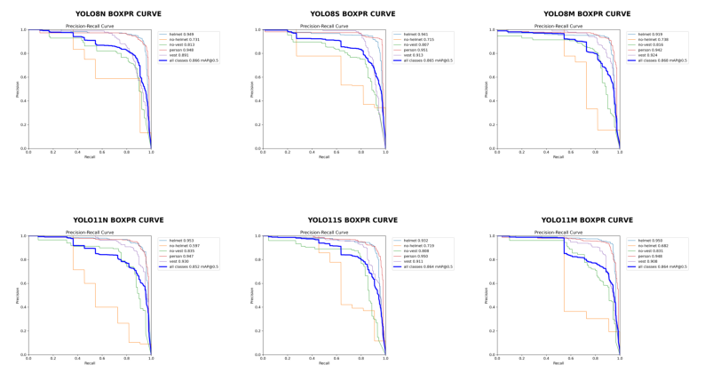

```python
display_image("YOLO_Baseline_Comparison_Grid.png", axis_show='off')
```

# Phase II. Processing. Data Augmentation and Final Model

Furthermore, the analysis revealed that no minority class appears isolated within the dataset images. Instead, these classes are mixed with majority classes such as **person** or **helmet**. This co-occurrence introduces an additional bias, complicating the model's ability to distinguish and generalize minority classes like **no-helmet** without being influenced by the presence of dominant categories.

```python
# All partitions (train + test + valid)
df_classes_before_oversampling = df_classes
df_classes_before_oversampling
```

|  | class_id | class_name | count | count_norm |
| --- | --- | --- | --- | --- |
| 0 | 3 | person | 7489 | 0.367793 |
| 1 | 0 | helmet | 6734 | 0.330714 |
| 2 | 4 | vest | 3481 | 0.170956 |
| 3 | 2 | no-vest | 2347 | 0.115264 |
| 4 | 1 | no-helmet | 311 | 0.015274 |

```python
# Train dataset Instances (BEFORE OVERSAMPLING)
class_names = data["names"]
print(class_names)

train_dataset_before_oversampling_dict = count_classes("train")
print(train_dataset_before_oversampling_dict)

# Converting into a Pandas df
data_classes = []

for class_id, count in train_dataset_before_oversampling_dict.items():
  class_name = class_names[class_id]
  data_classes.append({
      "class_id": class_id,
      "class_name": class_name,
      "count": count
  })

df_classes = pd.DataFrame(data_classes)

total_classes = df_classes["count"].sum()
df_classes["count_norm"] = df_classes["count"].apply(lambda x: x/total_classes).round(2)

df_classes.sort_values(by="count_norm", ascending=False).reset_index(drop=True)
```

```
['helmet', 'no-helmet', 'no-vest', 'person', 'vest']
Counter({3: 7034, 0: 6307, 4: 3211, 2: 2196, 1: 276})
```

|  | class_id | class_name | count | count_norm |
| --- | --- | --- | --- | --- |
| 0 | 3 | person | 7034 | 0.37 |
| 1 | 0 | helmet | 6307 | 0.33 |
| 2 | 4 | vest | 3211 | 0.17 |
| 3 | 2 | no-vest | 2196 | 0.12 |
| 4 | 1 | no-helmet | 276 | 0.01 |

### Oversampling

We can see above a significant disparity between the majority and minority classes. This imbalance often causes the model to overlook under-represented classes in an effort to minimize global loss. To mitigate this bias, a **Simple Random Oversampling** strategy is being implemented on the training set. This technique involved increasing the frequency of samples containing critical instances. Specifically, a duplication factor of **k=3** was applied to images featuring safety violations (**no-hardhat, no-vest**), while images showing regulatory compliance maintained a factor of **k=1**.

```python
import os
import shutil
from tqdm import tqdm

# Original paths
train_labels_path = f'{dataset.location}/train/labels/'
train_images_path = f'{dataset.location}/train/images/'

# #End path
# It redirects to the train_oversampled directory and creates the images and labels subdirectories
oversampled_path = f'{dataset.location}/train_oversampled'
os.makedirs(f'{oversampled_path}/images', exist_ok=True)
os.makedirs(f'{oversampled_path}/labels', exist_ok=True)

# It takes the IDs based on the data.yaml file
# 1: no-helmet, 2: no-vest
clases_criticas = ['1', '2']

print("Initing balancing process...")

for label_file in tqdm(os.listdir(train_labels_path)):

    # 1. Determine image filename (preserving original extension)
    # Search for an image file that matches the label filename
    base_name = os.path.splitext(label_file)[0]
    img_file = None
    for ext in ['.jpg', '.jpeg', '.png', '.JPG']:
        if os.path.exists(os.path.join(train_images_path, base_name + ext)):
            img_file = base_name + ext
            break

    if img_file is None: continue # Skip if no matching image is found

    # 2. Read labels to determine the duplication factor
    with open(os.path.join(train_labels_path, label_file), 'r') as f:
        lines = f.readlines()
        has_violation = any(line.split()[0] in clases_criticas for line in lines)

    # 3. Define factor: 3 copies for critical images, 1 copy for normal images
    factor = 3 if has_violation else 1

    for i in range(factor):
        new_name = f"aug_{i}_{base_name}"

        # Copy image file
        shutil.copy(os.path.join(train_images_path, img_file),
                    os.path.join(oversampled_path, f"images/{new_name}{os.path.splitext(img_file)[1]}"))

        # Copy label file
        shutil.copy(os.path.join(train_labels_path, label_file),
                    os.path.join(oversampled_path, f"labels/{new_name}.txt"))

print(f"\nOversampling completed. New dataset located at: {oversampled_path}")
```

```
Initing balancing process...
```

```
Oversampling completed. New dataset located at: /content/tfm_construction_roger-3/train_oversampled
```

By tripling the presence of minority classes, the model's loss function is forced to penalize errors in these categories more heavily. This approach aims to improve **Recall** in detecting false negatives without the need for additional data collection.

```python
# Train dataset Instances (AFTER OVERSAMPLING)
class_names = data["names"]

train_dataset_after_oversampling_dict = count_classes("train_oversampled")
print(train_dataset_after_oversampling_dict)

# Dataframe
data_classes = []

for class_id, count in train_dataset_after_oversampling_dict.items():
  class_name = class_names[class_id]
  data_classes.append({
      "class_id": class_id,
      "class_name": class_name,
      "count": count
  })

df_classes = pd.DataFrame(data_classes)

total_classes = df_classes["count"].sum()
df_classes["count_norm"] = df_classes["count"].apply(lambda x: x/total_classes).round(2)

df_classes.sort_values(by="count_norm", ascending=False).reset_index(drop=True)
```

```
Counter({3: 12942, 0: 11585, 2: 6588, 4: 4103, 1: 828})
```

|  | class_id | class_name | count | count_norm |
| --- | --- | --- | --- | --- |
| 0 | 3 | person | 12942 | 0.36 |
| 1 | 0 | helmet | 11585 | 0.32 |
| 2 | 2 | no-vest | 6588 | 0.18 |
| 3 | 4 | vest | 4103 | 0.11 |
| 4 | 1 | no-helmet | 828 | 0.02 |

Due to the high density of person and helmet labels in images containing no-vest and no-helmet, the count of dominant classes has inevitably increased. However, in terms of percentage, no-vest now ranks as the third most frequent class, while vest has moved to fourth. Conversely, no-helmet remains the least represented category because the original dataset contained very few records, making it extremely difficult to significantly increase the quantity of these labels.

The goal of this oversampling is to ensure the model learns from a greater number of records for no-helmet and no-vest—specifically, from the non-predominant classes.

This technique may lead to model overfitting, which is why it will be crucial to configure the model and activate specific data augmentation hyperparameters. To evaluate the performance, I will use mAP (mean Average Precision) per class and the Recall and F1-Score for the minority classes.

### Data Augmentation

It is important to highlight that, prior to training, the Roboflow platform was used to apply an "Offline" data augmentation stage (using random rotations between -15° and +15°) in order to increase the sample volume of the original dataset.

**Training Refinement: Integration of Native Data Augmentation**

Once the non-predominant classes were bolstered through oversampling, the model was retrained using this enhanced dataset alongside a strategic adjustment of hyperparameters. YOLO models facilitate native data augmentation by integrating transformations directly into the training pipeline, which significantly accelerates both the processing and training phases.

To enhance the model's generalization capabilities, the following augmentation parameters were implemented:

```python
augmentation_params = {
    "hsv_h": 0.015,      # Adjusts hue to simulate different lighting/weather conditions
    "hsv_s": 0.7,        # Controls saturation for color vividness variety
    "hsv_v": 0.4,        # Modifies brightness levels for light invariance
    "degrees": 10.0,     # Slight rotations to handle worker pose changes and head tilts
    "translate": 0.1,    # Shifts images to manage off-center framing or partial occlusions
    "scale": 0.6,        # Rescales objects to improve detection at varying distances
    "perspective": 0.001,# Compensates for distortions from elevated camera viewpoints
    "copy_paste": 0.6,   # High probability to leverage the oversampled "catalog" of rare classes
    "mixup": 0.15,       # Blends images to enhance robustness against site occlusions
    "mosaic": 1.0,       # Combines 4 images to train on high-density, cluttered environments
    "cls": 2.0           # Doubled weight for classification loss to prioritize critical PPE classes
}
```

Furthermore, implementing **Mosaic=1.0** during the training pipeline acts as a powerful regularizer that synthetically simulates **distance variability**. By forcing the model to process objects at reduced scales within high-density contexts (merging four images into one), we significantly enhance its robustness for **long-range detection**. This ensures the system remains reliable even when workers are positioned far from the camera lens.

While these techniques maximize detection accuracy for small objects, they lead to a significant **increase in training time** since it the training requires substantial computational resources from the GPU.

Before passing the data.yaml file to the model, I had to modify it so that it references the path of the newly created folder: /tfm_construction_roger-3/train_oversampled/images.

```python
# Open the file in read mode ('r') to get the current configuration
with open(f'{base_path}/data.yaml', 'r') as file:
    data = yaml.safe_load(file)

data
```

```
{'names': ['helmet', 'no-helmet', 'no-vest', 'person', 'vest'],
 'nc': 5,
 'roboflow': {'license': 'CC BY 4.0',
  'project': 'construction-safety-gsnvb-4gguw',
  'url': 'https://universe.roboflow.com/rogergs94/construction-safety-gsnvb-4gguw/dataset/3',
  'version': 3,
  'workspace': 'rogergs94'},
 'test': '../test/images',
 'train': '../train/images',
 'val': '../valid/images'}
```

```python
# Update the variable 'train' with the new_path
new_path = "../train_oversampled/images"
data["train"] = new_path

# Save the changes in a file with 'w' mode
with open(f'{base_path}/data.yaml', 'w') as file:
    yaml.dump(data, file, default_flow_style=False)

print(f"New training path updated to: {data['train']}")
```

```
New training path updated to: ../train_oversampled/images
```

### Training (Post processing) - YOLOv8n

```python
# Training with Data Augmentation (YOLO PIPELINE) - YOLOv8n
model_name = "yolov8n"
model = YOLO(f"{model_name}.pt")

# Project naming for tracking experiments:
project=f"TFM_{model_name}_{today}_WITH_Data_Aug_1280"
name=f"modelo_{model_name}_optimized_50epochs_1280"

# Model training
model.train(
    data=f'{dataset.location}/data.yaml', # Path to the configuration file defining class names and dataset paths.
    project=project,                      # Name of the main project directory to group related experiments.
    name=name,                            # Specific identifier for this run (creates a subfolder within the project).
    epochs=50,                            # Maximum number of complete passes through the training dataset.
    patience=15,                          # Early Stopping: halts training if no improvement is seen after 15 epochs.
    seed=42,                              # Sets a fixed random seed to ensure experimental reproducibility.
    imgsz=640,                            # Input image resolution; balances detection detail with computational cost.
    freeze=0,                             # Number of initial layers to freeze; 0 indicates full-network fine-tuning.
    box=5,                                # Weight gain for the bounding box regression loss in the total cost function.
    save_period=1,                        # Frequency (in epochs) at which model checkpoints are saved.
    lr0=0.001,                            # Initial learning rate for the optimizer's weight update steps.
    optimizer="AdamW",                    # Optimization algorithm with decoupled weight decay for better generalization.
    label_smoothing=0.1,                  # Regularization that prevents overconfidence by softening target labels.
    weight_decay=0.0005,                  # L2 penalty applied to weights to prevent growth and reduce overfitting.
    # Data augmentation:
    **augmentation_params                 # Unpacks and applies stochastic transforms (Mosaic, Mixup, etc.) to the pipeline.
)

# Model validation
results_data_augm = model.val()

# Performance Metrics
print("\n--- FINAL METRICS (Optimized Model) ---")
print(f"mAP@50: {results_data_augm.box.map50:.4f}")
print(f"mAP50-95: {results_data_augm.box.map:.4f}")
print(f"Recall global: {results_data_augm.box.mr:.4f}") # mp=mean precision, mr=mean recall

print("\n--- CLASS-SPECIFIC RECALL ---")
for i, class_name in enumerate(results_data_augm.names.values()):
    # Index [1] of class_result corresponds to Recall
    recall_class = results_data_augm.box.class_result(i)[1]
    print(f"Class Recall {class_name}: {recall_class:.4f}")
```

[output not shown]

[output cut: 285 more lines]

```
                  vest         74        141      0.885      0.865      0.916      0.525
Speed: 6.8ms preprocess, 4.6ms inference, 0.0ms loss, 4.1ms postprocess per image
Results saved to /content/runs/detect/val2

--- FINAL METRICS (Optimized Model) ---
mAP@50: 0.9026
mAP50-95: 0.4949
Recall global: 0.8534

--- CLASS-SPECIFIC RECALL ---
Class Recall helmet: 0.9483
Class Recall no-helmet: 0.6815
Class Recall no-vest: 0.8178
Class Recall person: 0.9544
Class Recall vest: 0.8652
```

```python
# Download my model "project" into a zip
zip_name = f"{name}.zip"
folder_to_zip = f"/content/runs/detect/{project}/{name}"

os.system(f"zip -r {zip_name} {folder_to_zip}")

files.download(zip_name)
```

# Inference (Predictions)

```python
from google.colab.patches import cv2_imshow
```

```python
my_model = YOLO("/content/best.pt")
```

```python
print("Classes:", my_model.names)
```

```
Classes: {0: 'helmet', 1: 'no-helmet', 2: 'no-vest', 3: 'person', 4: 'vest'}
```

```python
image = "https://media.istockphoto.com/id/2117759132/photo/four-construction-workers-having-meeting.jpg?s=612x612&w=0&k=20&c=qLV__HuqWfnV9RWbXgzQDrYxsmQXbDRm4RO-RP9vEIs="

# Model Predict in an image
results_to_img = my_model.predict(image, save=True, conf=0.1, iou=0.50)

# Data of the first result
boxes = results_to_img[0].boxes
#print(boxes)

print(f"Objects in the image: {len(boxes)}")
```

```
Found https://media.istockphoto.com/id/2117759132/photo/four-construction-workers-having-meeting.jpg locally at four-construction-workers-having-meeting.jpg
image 1/1 /content/four-construction-workers-having-meeting.jpg: 448x640 4 helmets, 4 persons, 4 vests, 12.5ms
Speed: 3.0ms preprocess, 12.5ms inference, 3.1ms postprocess per image at shape (1, 3, 448, 640)
Results saved to /content/runs/detect/predict
Objects in the image: 12
```

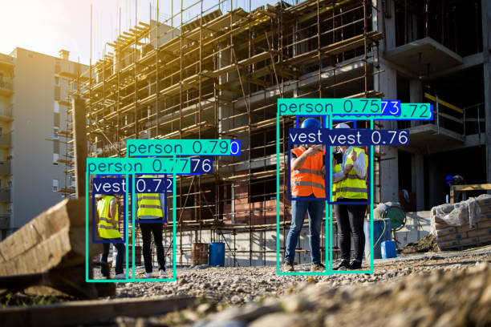

```python
# Annotated predicted image
res = results_to_img[0]
annotated_pred_image = res.plot()

# Display or Save
cv2_imshow(annotated_pred_image)
```

# Extra 1. Genetic hyperparameter tuning / Grid Search (model.tune)

To optimize the YOLO model's performance, I implemented a hyperparameter search using the native **tune()** method.

In this phase, the model was initialized using the weights from the previous best-performing run (best.pt). By building upon an already refined model, the tuning process starts from a state of higher specialized knowledge rather than generic pre-trained weights.

To further refine the model, a specialized search space was defined for the `tune()` method, targeting both optimization and augmentation parameters. This approach ensures that the model reaches its maximum potential by mathematically determining the best combination of variables.

**Optimization Parameters**

- **Initial Learning Rate (`lr0`)**: Searched between $10^{-5}$ and $10^{-1}$ to stabilize convergence.
- **Momentum**: Explored up to a value of **0.937** to determine how much previous gradient updates should influence the current direction, helping the model navigate complex loss surfaces.
- **Weight Decay**: A range up to **0.001** was included to act as a regularizer, preventing the model from overfitting on the oversampled minority classes.

In addition to core parameter optimization, it is also possible to tune hyperparameters for data augmentation and loss weighting. However, to manage the computational load and optimize processing time, these specific variables were excluded from the tuning search space:

**Augmentation and Loss Weighting**

```python
# Define search space
search_space = {
    # Optimization hiperparamst
    "lr0": (1e-5, 1e-1),
    "momentum": (0.7, 0.937),
    "weight_decay": (0.0, 0.001), # Regularization to avoid overfitting

    # Data Augmentation hiperparams
    #"copy_paste": (0.6, 0.8),
    #"mixup": (0.15, 0.3),
    #"degrees": (0.0, 45.0),
    #"cls": (1.0, 2.5),
}
```

```python
# Initialize the YOLO model

path_best_pt = f"/content/runs/detect/{project}/{name}/weights/best.pt"
path_best_pt = "/content/best.pt"
model = YOLO(path_best_pt)


# Grid search
model.tune(
    data=f"{dataset.location}/data.yaml",
    epochs=20,
    seed=42,
    iterations=100,
    optimizer="AdamW",
    space=search_space,
    plots=False,
    save=False,
    val=False,
)
```

[output not shown]

### Re-Training with the best hiperparameters

```python
final_params = {
    "lr0": 1e-5,
    "momentum": 0.937,
    "weigth_decay": 0.001
    }
```

```python
# Training with best hiperparameters (Grid Search)
model_name = "yolo8n" #it must match the same model that was trained in best.pt
model = YOLO(f"{model_name}.pt")

# Project naming for tracking experiments:
project=f"TFM_{model_name}_{today}_WITH_grid_search"
name=f"modelo_{model_name}_girdsearch_optimized_50epochs"

model.train(
    data=f'{dataset.location}/data.yaml',
    epochs=50,
    patience=8,
    seed=0.42,
    imgsz=1280,
    project=project,
    name=name,
    save_period=-1,
    **final_params
)

# Model validation
results_data_augm = model.val()


# Performance Metrics
print("\n--- FINAL METRICS (Optimized Model) ---")
print(f"mAP@50: {results_data_augm.box.map50:.4f}")
print(f"mAP50-95: {results_data_augm.box.map:.4f}")
print(f"Recall global: {results_data_augm.box.mr:.4f}") # mp=mean precision, mr=mean recall

print("\n--- CLASS-SPECIFIC RECALL ---")
for i, class_name in enumerate(results_data_augm.names.values()):
    # Index [1] of class_result corresponds to Recall
    recall_class = results_data_augm.box.class_result(i)[1]
    print(f"Class Recall {class_name}: {recall_class:.4f}")
```

# Extra 2. LAST MODEL (YOLO26) - Training (Post Processing) - YOLOv26n with 1280 imgsz

As future lines of work, we can opt to tran the latest YOLO model (YOLO26) and compare it to my current model to see if it has notable differences:

```python
# Training with Data Augmentation (YOLO PIPELINE) - YOLO26n
model_name = "yolo26n"
model = YOLO(f"{model_name}.pt")

# Project naming for tracking experiments:
project=f"TFM_{model_name}_{today}_WITH_Data_Aug"
name=f"modelo_{model_name}_optimized_50epochs"

# Model training
model.train(
    data=f'{dataset.location}/data.yaml',
    epochs=50,
    patience=8,
    imgsz=1280,
    project=project,
    name=name,
    save_period=1,
    weight_decay=0.0005,
    #Data augmentation:
    **augmentation_params
)

# Model validation
results_data_augm = model.val()


# Performance Metrics
print("\n--- FINAL METRICS (Optimized Model) ---")
print(f"mAP@50: {results_data_augm.box.map50:.4f}")
print(f"mAP50-95: {results_data_augm.box.map:.4f}")
print(f"Recall global: {results_data_augm.box.mr:.4f}") # mp=mean precision, mr=mean recall

print("\n--- CLASS-SPECIFIC RECALL ---")
for i, class_name in enumerate(results_data_augm.names.values()):
    # Index [1] of class_result corresponds to Recall
    recall_class = results_data_augm.box.class_result(i)[1]
    print(f"Class Recall {class_name}: {recall_class:.4f}")
```

```python
# Download my model "project" into a zip
folder_to_zip = f"{project}/{name}"
zip_name = f"{model_name}_results.zip"

print(f"Zipping results from: {folder_to_zip}")

!zip -r {zip_name} {folder_to_zip}
files.download(zip_name)
```